# Como a desigualdade espelha o mapa do voto estadual mineiro 13/07/2024

## Introdução

Tal estudo pretende analisar os efeitos que a desigualdade tem sobre o mapa eleitoral mineiro. Concentrado a análise sobre os votos para governador em 2018, a hipótese do trabalho é a correlação entre votos do governador Zema com os menores índices de desigualdade gini, ou seja, regiões mais ricas do estado. Para tanto, analisaremos o mapa eleitoral de minas, calculando o quanto cada candidato a governador teve de votos por município. A par disso, será feito um modelo de regressão linear associando os votos ao Zema com os dados de gini por município. A hipótese do trabalho se demonstrou verídica, como bem constatado na análise de efeitos marginais e no gráfico de dispersão.

## Bibliotecas utilizadas

```r
# usando o pacote pacman para carregar todas as outras bibliotecas

pacman::p_load(rio, tidyverse, janitor, scales, geobr, electionsBR, stargazer, geobr, terra, gtools, codesBR)

# devtools::install_github("meirelesff/codesBR")

# criação de mapa
pacman::p_load(terra, ggspatial, mapview, geobr, terra)
```

## Bases de Dados

A biblioteca electionsBR contem puxa dados eleitorais direto do TSE; O índice gini foi baixado um arquivo csv do site do IBGE Coordenadas são da bibilioteca geobr

### Dados eleitorais

```r
# votos por partido em cada zona eleitoral da disputa de 2018
mg2018 <- electionsBR::elections_tse(year = 2018, type = 'party_mun_zone', uf = 'MG')
```

```
## Processing the data...
```

```
## Done.
```

### Gini

```r
# gini
gini <- read.csv("gini_2010.csv")
```

### Coordenadas municípios

```r
# coordenadas dos municípios
ceps_mg <- read_municipality(year = 2018, showProgress = T)
```

```
## Using year/date 2018
```

```r
# filtrando apenas MG
ceps_mg <- ceps_mg %>%
  filter(abbrev_state == 'MG')
```

## Manipulando as variáveis eleitorais

### Selecionando as variáveis relevantes da base de dados

```r
mg2018_edit <- mg2018 %>%
  select(municipio = NM_MUNICIPIO, codigo_mun = CD_MUNICIPIO, partido = SG_PARTIDO,
         estado = SG_UF, cargo = DS_CARGO, partido = SG_PARTIDO, votos_legenda = QT_VOTOS_LEGENDA_VALIDOS,
         votos_nominais = QT_VOTOS_NOMINAIS_VALIDOS, turno = NR_TURNO)


# organizando em ordem alfabética
mg2018_edit <- mg2018_edit %>%
  arrange(municipio)
```

### Selecionando o cargo de governador e criando a variavel total de votos

Total de votos significa a soma dos votos que a legenda recebeu junto do voto nominal do candidato

```r
# selecionando o cargo governador

mg2018_edit <- mg2018_edit %>%
  filter(cargo == 'Governador', turno == 1)

# criando variavel total de votos

mg2018_edit <-  mg2018_edit %>%
  mutate(votos_partido = votos_legenda + votos_nominais)
```

### Análise dos votos por Município

Aqui somamos os votos que o candidato recebeu no município, visto que muitos possuem varias seções eleitorais A partir de agora, temos o percentual de votos que cada chapa recebeu em cada município

```r
# total de votos por municipio
mg2018_edit <- mg2018_edit %>%
  group_by(municipio) %>%
  mutate(voto_municipio = sum(votos_partido))

# porcentagem de votos do partido no municipio
mg2018_edit <- mg2018_edit %>%
  mutate(percentual = votos_partido/voto_municipio)
```

### Visualizando apenas o partido do Zema (Novo)

```r
# filtrando o NOVO
novo_mg2018 <- mg2018_edit %>%
  filter(partido == 'NOVO') %>%
  arrange(municipio)
```

### Removendo duplicatas

```r
# removendo duplicatas
# alguns municipios se repetem por conta de ter varios cartorios eleitorais
# somei o percentual por municipio e retirei as duplicatas da variavel total percentual
novo_mg2018_edit2 <- novo_mg2018 %>%
  group_by(municipio) %>%
  mutate(percentual_total = sum(percentual)) %>%
  filter(!(duplicated(percentual_total)))
```

## Tratando a variavel codigo municipal

Esse passo é importante, pois é o codigo do município é a ponte entre as duas bases de dados (gini e eleitoral)

```r
# convertendo a variavel em character
novo_mg2018_edit2 <- novo_mg2018_edit2 %>%
  mutate(codigo_mun = as.character(codigo_mun))

# passando do tse para ibge a base de votação
novo_mg2018_edit2 <-  novo_mg2018_edit2 %>%
  codesBR::ibge_from_tse(codigo_mun)
```

### Corrigindo um erro no codigo IBGE

Por algum motivo, na base gini o cod_ibge está sem o ultimo digito. Por conta disso, teremos que retirar o ultimo digito tanto da base eleitoral quanto da base dos dados das coordenadas municipais

```r
### ERRO: NA BASE GINI > o codigo é do IBGE, mas está faltando o ultimo digito

novo_mg2018_edit2 %>%
  filter(municipio %in% c('BELO HORIZONTE', 'CONTAGEM')) %>%
  select(cod_ibge)
```

```
## # A tibble: 2 × 2
## # Groups:   municipio [2]
##   municipio      cod_ibge
##   <chr>          <chr>
## 1 BELO HORIZONTE 3106200
## 2 CONTAGEM       3118601
```

```r
# BH = 310620
# CTG = 311860

gini %>%
  filter(municipio %in% c('belo horizonte', 'contagem')) %>%
  select(codigo)
```

```
##   codigo
## 1 310620
## 2 311860
```

```r
# BH = 310620
# CTG = 311860

# retirando o ultimo numero da base de votação
# dessa forma as observações de ambas as colunas ficam iguais
novo_mg2018_edit2 <- novo_mg2018_edit2 %>%
  mutate(cod_ibge = str_sub(cod_ibge, end = 6))
```

## Base Gini

### Tratando a variável cod_ibge

```r
# deixando a coluna de referencia com o mesmo nome em ambas

gini <- gini %>%
  rename(cod_ibge = codigo)

gini_2 <- gini %>%
  select(cod_ibge, gini)

# deixando as duas variaveis na mesma forma de dado
gini_2 <- gini_2 %>%
  mutate(cod_ibge = as.character(cod_ibge))
```

## Base municípios

Teremos que tratar a variável codigo para conseguir juntar com as outras bases. Efetuaremos as mesmas operacoes: converter em character, renomeando e eliminando o último dígito.

### Tratando a variável cod_ibge

```r
# transformando em character
ceps_mg <- ceps_mg %>%
  mutate(code_muni = as.character(code_muni))

# renomeando
ceps_mg <- ceps_mg %>%
  rename(cod_ibge = code_muni)

# eliminando o ultimo digito pra conseguir juntar as bases

ceps_mg <- ceps_mg %>%
  mutate(cod_ibge = str_sub(cod_ibge, end = 6))
```

## Juntando as bases

```r
# usando o argumento left join para trazer o indice gini
novo_mg2018_edit2 <- novo_mg2018_edit2 %>%
  left_join(gini_2, by = 'cod_ibge')


# agora com os dodos geograficos
novo_mg2018_edit2 <- novo_mg2018_edit2 %>%
  left_join(ceps_mg, by = "cod_ibge")
```

## Análises

### Efeitos marginais da regressão

Ao analisar os efeitos marginais, a variavel percentual_total é a dependente, enquanto que a gini é independente. A par disso, queremos analisar como o índice gini influencia os votos no partido Novo/Zema.

```r
library(stargazer)

m1 <- lm(percentual_total ~ gini, data = novo_mg2018_edit2)

stargazer(m1, type = 'text')
```

```
##
## ===============================================
##                         Dependent variable:
##                     ---------------------------
##                          percentual_total
## -----------------------------------------------
## gini                         -0.384***
##                               (0.096)
##
## Constant                     0.522***
##                               (0.047)
##
## -----------------------------------------------
## Observations                    853
## R2                             0.018
## Adjusted R2                    0.017
## Residual Std. Error      0.151 (df = 851)
## F Statistic           15.896*** (df = 1; 851)
## ===============================================
## Note:               *p<0.1; **p<0.05; ***p<0.01
```

### Resultados efeitos marginais

Ao analisar o efeito da regressao, é visível que há significância estatística entre votos o aumento do Gini influenciando a perda de votos no candidato Zema. Trocando em miúdos, municípios que são mais desiguais (indice gini como variável proxy de desigualdade) votaram menos nessse candidato. No qual o aumento de 1 ponto no gini diminui em média 38.4% de votos no candidato do partido NOVO.

### Análise gráfica - Scatterplot

O gráfico de dispersão permite visualizar os resultados da regressão, no qual a variavel independente (eixo x) é o índice gini, enquanto que a variavel dependente (eixo y) são os votos para governador.

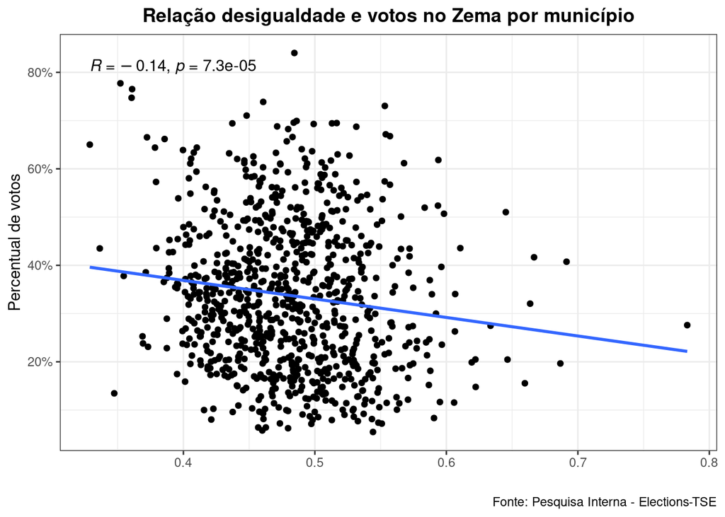

```r
novo_mg2018_edit2 %>%
  ggplot(aes(x = gini, y = percentual_total)) +
  geom_point() +
  geom_smooth(method = 'lm', se = F) +
  labs(title = 'Relação desigualdade e votos no Zema por município',
       caption = 'Fonte: Pesquisa Interna - Elections-TSE',
       x = '',
       y = 'Percentual de votos') +
  theme_bw() +
  theme(plot.title = element_text(face = 'bold',hjust = 0.5)) +
  scale_y_continuous(labels = percent) +
  ggpubr::stat_cor()
```

### Mapa do voto mineiro

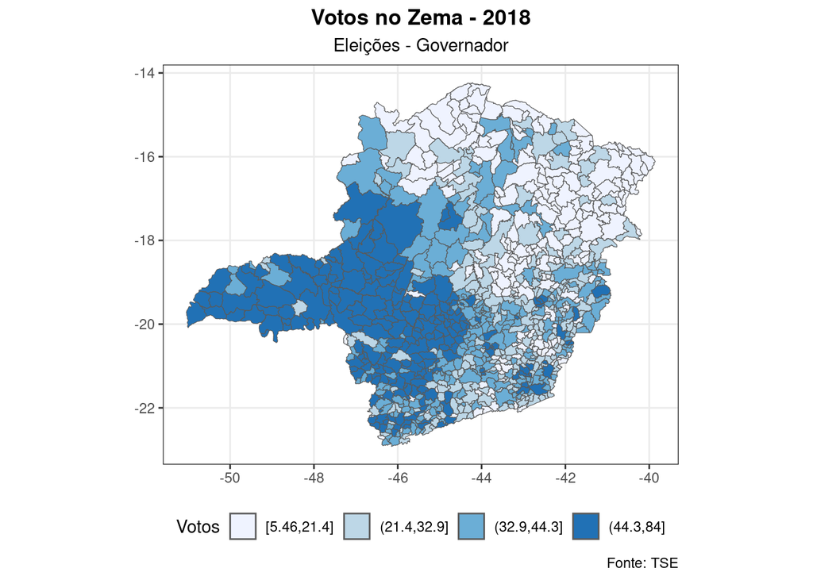

```r
# transformando o percentual de votos em porcentagem
novo_mg2018_edit2 <- novo_mg2018_edit2 %>%
  mutate(percentual_total = percentual_total*100)

# criando categorias da variavel percentual_total
library(dplyr)
novo_mg2018_edit2$percentual_qc <- quantcut(novo_mg2018_edit2$percentual_total, 4)

# codigo para visualizar o mapa
novo_mg2018_edit2 %>%
  ggplot() +
  geom_sf(aes(fill = percentual_qc, geometry = geom)) +
  scale_fill_brewer(palette = "Blues") +
  labs(title = 'Votos no Zema - 2018',
       subtitle = 'Eleições - Governador',
       caption = 'Fonte: TSE',
       fill = 'Votos') +
  theme_bw() +
  theme(plot.title = element_text(face = 'bold', hjust = .5),
        plot.subtitle = element_text(hjust = .5),
        legend.position = "bottom")
```